# **Problem Statement**

```python
start_3 = time.time()
history_3 = model_3.fit(X_train, y_train, validation_data=(X_val, y_val), batch_size=batch_size, epochs=epochs, class_weight=class_weights_dict)
end_3 = time.time()
```

```
438/438 ━━━━━━━━━━━━━━━━━━━━ 2s 3ms/step - Recall: 0.8057 - loss: 0.4228 - val_Recall: 0.8889 - val_loss: 0.2963
438/438 ━━━━━━━━━━━━━━━━━━━━ 1s 2ms/step - Recall: 0.8752 - loss: 0.3156 - val_Recall: 0.8709 - val_loss: 0.2104
438/438 ━━━━━━━━━━━━━━━━━━━━ 1s 2ms/step - Recall: 0.8880 - loss: 0.2816 - val_Recall: 0.8709 - val_loss: 0.1800
438/438 ━━━━━━━━━━━━━━━━━━━━ 1s 2ms/step - Recall: 0.8790 - loss: 0.2614 - val_Recall: 0.8919 - val_loss: 0.2583
438/438 ━━━━━━━━━━━━━━━━━━━━ 1s 2ms/step - Recall: 0.8842 - loss: 0.2374 - val_Recall: 0.8799 - val_loss: 0.2193
438/438 ━━━━━━━━━━━━━━━━━━━━ 1s 2ms/step - Recall: 0.8880 - loss: 0.2298 - val_Recall: 0.8799 - val_loss: 0.1956
438/438 ━━━━━━━━━━━━━━━━━━━━ 1s 2ms/step - Recall: 0.8983 - loss: 0.2244 - val_Recall: 0.8709 - val_loss: 0.1737
438/438 ━━━━━━━━━━━━━━━━━━━━ 1s 2ms/step - Recall: 0.8867 - loss: 0.2236 - val_Recall: 0.8769 - val_loss: 0.1796
438/438 ━━━━━━━━━━━━━━━━━━━━ 1s 2ms/step - Recall: 0.8996 - loss: 0.2075 - val_Recall: 0.8829 - val_loss: 0.1616
438/438 ━━━━━━━━━━━━━━━━━━━━ 1s 3ms/step - Recall: 0.8945 - loss: 0.2038 - val_Recall: 0.8799 - val_loss: 0.1364
438/438 ━━━━━━━━━━━━━━━━━━━━ 1s 2ms/step - Recall: 0.9060 - loss: 0.1923 - val_Recall: 0.8829 - val_loss: 0.1750
438/438 ━━━━━━━━━━━━━━━━━━━━ 1s 2ms/step - Recall: 0.8970 - loss: 0.2058 - val_Recall: 0.8859 - val_loss: 0.1592
438/438 ━━━━━━━━━━━━━━━━━━━━ 1s 2ms/step - Recall: 0.9073 - loss: 0.1966 - val_Recall: 0.8859 - val_loss: 0.1610
438/438 ━━━━━━━━━━━━━━━━━━━━ 1s 2ms/step - Recall: 0.9073 - loss: 0.1873 - val_Recall: 0.8919 - val_loss: 0.1540
438/438 ━━━━━━━━━━━━━━━━━━━━ 1s 2ms/step - Recall: 0.9112 - loss: 0.1894 - val_Recall: 0.8829 - val_loss: 0.1442
438/438 ━━━━━━━━━━━━━━━━━━━━ 1s 2ms/step - Recall: 0.9060 - loss: 0.1878 - val_Recall: 0.8889 - val_loss: 0.1371
438/438 ━━━━━━━━━━━━━━━━━━━━ 1s 2ms/step - Recall: 0.9073 - loss: 0.1824 - val_Recall: 0.8889 - val_loss: 0.1520
438/438 ━━━━━━━━━━━━━━━━━━━━ 1s 2ms/step - Recall: 0.9112 - loss: 0.1840 - val_Recall: 0.8829 - val_loss: 0.1059
438/438 ━━━━━━━━━━━━━━━━━━━━ 1s 2ms/step - Recall: 0.9022 - loss: 0.1835 - val_Recall: 0.8889 - val_loss: 0.1399
438/438 ━━━━━━━━━━━━━━━━━━━━ 1s 2ms/step - Recall: 0.9138 - loss: 0.1751 - val_Recall: 0.8889 - val_loss: 0.1439
438/438 ━━━━━━━━━━━━━━━━━━━━ 1s 2ms/step - Recall: 0.9125 - loss: 0.1782 - val_Recall: 0.8829 - val_loss: 0.1178
438/438 ━━━━━━━━━━━━━━━━━━━━ 2s 4ms/step - Recall: 0.9163 - loss: 0.1753 - val_Recall: 0.8859 - val_loss: 0.1115
438/438 ━━━━━━━━━━━━━━━━━━━━ 2s 2ms/step - Recall: 0.9125 - loss: 0.1770 - val_Recall: 0.8919 - val_loss: 0.1418
438/438 ━━━━━━━━━━━━━━━━━━━━ 1s 2ms/step - Recall: 0.9035 - loss: 0.1839 - val_Recall: 0.8919 - val_loss: 0.1206
438/438 ━━━━━━━━━━━━━━━━━━━━ 1s 2ms/step - Recall: 0.9151 - loss: 0.1727 - val_Recall: 0.8919 - val_loss: 0.1318
438/438 ━━━━━━━━━━━━━━━━━━━━ 1s 2ms/step - Recall: 0.9099 - loss: 0.1691 - val_Recall: 0.8919 - val_loss: 0.1158
438/438 ━━━━━━━━━━━━━━━━━━━━ 1s 2ms/step - Recall: 0.9073 - loss: 0.1746 - val_Recall: 0.8949 - val_loss: 0.1335
438/438 ━━━━━━━━━━━━━━━━━━━━ 1s 2ms/step - Recall: 0.9125 - loss: 0.1658 - val_Recall: 0.8979 - val_loss: 0.1299
438/438 ━━━━━━━━━━━━━━━━━━━━ 1s 2ms/step - Recall: 0.9086 - loss: 0.1652 - val_Recall: 0.9009 - val_loss: 0.1371
438/438 ━━━━━━━━━━━━━━━━━━━━ 1s 2ms/step - Recall: 0.9138 - loss: 0.1600 - val_Recall: 0.8949 - val_loss: 0.1357
438/438 ━━━━━━━━━━━━━━━━━━━━ 1s 2ms/step - Recall: 0.9151 - loss: 0.1568 - val_Recall: 0.8919 - val_loss: 0.1023
438/438 ━━━━━━━━━━━━━━━━━━━━ 2s 5ms/step - Recall: 0.9189 - loss: 0.1691 - val_Recall: 0.8979 - val_loss: 0.1383
438/438 ━━━━━━━━━━━━━━━━━━━━ 1s 2ms/step - Recall: 0.9176 - loss: 0.1596 - val_Recall: 0.8889 - val_loss: 0.1172
438/438 ━━━━━━━━━━━━━━━━━━━━ 1s 2ms/step - Recall: 0.9151 - loss: 0.1631 - val_Recall: 0.8979 - val_loss: 0.1355
438/438 ━━━━━━━━━━━━━━━━━━━━ 1s 2ms/step - Recall: 0.9125 - loss: 0.1644 - val_Recall: 0.8949 - val_loss: 0.1230
438/438 ━━━━━━━━━━━━━━━━━━━━ 1s 2ms/step - Recall: 0.9241 - loss: 0.1558 - val_Recall: 0.8889 - val_loss: 0.1201
438/438 ━━━━━━━━━━━━━━━━━━━━ 1s 2ms/step - Recall: 0.9176 - loss: 0.1601 - val_Recall: 0.8919 - val_loss: 0.1116
438/438 ━━━━━━━━━━━━━━━━━━━━ 1s 2ms/step - Recall: 0.9125 - loss: 0.1651 - val_Recall: 0.8919 - val_loss: 0.1153
438/438 ━━━━━━━━━━━━━━━━━━━━ 1s 2ms/step - Recall: 0.9228 - loss: 0.1566 - val_Recall: 0.8919 - val_loss: 0.1116
438/438 ━━━━━━━━━━━━━━━━━━━━ 1s 2ms/step - Recall: 0.9189 - loss: 0.1536 - val_Recall: 0.8859 - val_loss: 0.1292
438/438 ━━━━━━━━━━━━━━━━━━━━ 1s 3ms/step - Recall: 0.9125 - loss: 0.1600 - val_Recall: 0.8919 - val_loss: 0.1305
438/438 ━━━━━━━━━━━━━━━━━━━━ 1s 3ms/step - Recall: 0.9176 - loss: 0.1544 - val_Recall: 0.8859 - val_loss: 0.0993
438/438 ━━━━━━━━━━━━━━━━━━━━ 1s 3ms/step - Recall: 0.9151 - loss: 0.1606 - val_Recall: 0.8949 - val_loss: 0.1125
438/438 ━━━━━━━━━━━━━━━━━━━━ 1s 2ms/step - Recall: 0.9176 - loss: 0.1509 - val_Recall: 0.8919 - val_loss: 0.1128
438/438 ━━━━━━━━━━━━━━━━━━━━ 1s 2ms/step - Recall: 0.9176 - loss: 0.1521 - val_Recall: 0.8949 - val_loss: 0.1168
438/438 ━━━━━━━━━━━━━━━━━━━━ 1s 2ms/step - Recall: 0.9202 - loss: 0.1452 - val_Recall: 0.8919 - val_loss: 0.1313
438/438 ━━━━━━━━━━━━━━━━━━━━ 1s 2ms/step - Recall: 0.9151 - loss: 0.1560 - val_Recall: 0.8889 - val_loss: 0.1103
438/438 ━━━━━━━━━━━━━━━━━━━━ 1s 2ms/step - Recall: 0.9163 - loss: 0.1586 - val_Recall: 0.8889 - val_loss: 0.1226
438/438 ━━━━━━━━━━━━━━━━━━━━ 1s 3ms/step - Recall: 0.9151 - loss: 0.1554 - val_Recall: 0.8919 - val_loss: 0.1069
438/438 ━━━━━━━━━━━━━━━━━━━━ 1s 2ms/step - Recall: 0.9189 - loss: 0.1546 - val_Recall: 0.8919 - val_loss: 0.1188
```

```python
print("Time taken in seconds ", end_3 - start_3)
```

```
Time taken in seconds  53.41545629501343
```

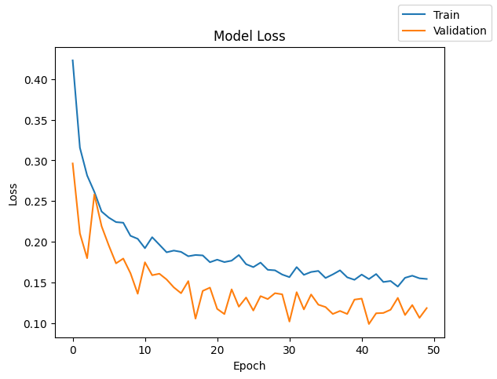

```python
plot(history_3, 'loss')
```

- Both training and validation loss decrease steadily, indicating the model is learning effectively and converging well.
- Validation loss remains close to or lower than training loss throughout training, suggesting minimal overfitting and good generalization.
- The loss curve begins to stabilize after ~30 epochs, indicating the model is nearing optimal learning and additional epochs may provide limited improvement.

```python
model_3_train_perf = model_performance_classification(model_3, X_train, y_train)
model_3_train_perf
```

```
438/438 ━━━━━━━━━━━━━━━━━━━━ 1s 2ms/step
```

|  | Accuracy | Recall | Precision | F1 Score |
| --- | --- | --- | --- | --- |
| 0 | 0.988857 | 0.960183 | 0.936974 | 0.948235 |

```python
model_3_val_perf = model_performance_classification(model_3, X_val, y_val)
model_3_val_perf
```

```
188/188 ━━━━━━━━━━━━━━━━━━━━ 0s 2ms/step
```

|  | Accuracy | Recall | Precision | F1 Score |
| --- | --- | --- | --- | --- |
| 0 | 0.986667 | 0.942064 | 0.932303 | 0.937121 |

```python
y_train_pred_3 = model_3.predict(X_train)
y_val_pred_3 = model_3.predict(X_val)
```

```
438/438 ━━━━━━━━━━━━━━━━━━━━ 1s 3ms/step
188/188 ━━━━━━━━━━━━━━━━━━━━ 0s 1ms/step
```

```python
print("Classification Report - Train data Model_3", end="\n\n")
cr_train_model_3 = classification_report(y_train, y_train_pred_3 > 0.5)
print(cr_train_model_3)
```

```
Classification Report - Train data Model_3

              precision    recall  f1-score   support

         0.0       1.00      0.99      0.99     13223
         1.0       0.88      0.93      0.90       777

    accuracy                           0.99     14000
   macro avg       0.94      0.96      0.95     14000
weighted avg       0.99      0.99      0.99     14000
```

```python
print("Classification Report - Validation data Model_3", end="\n\n")
cr_val_model_3 = classification_report(y_val, y_val_pred_3 > 0.5)
print(cr_val_model_3)
```

```
Classification Report - Validation data Model_3

              precision    recall  f1-score   support

         0.0       0.99      0.99      0.99      5667
         1.0       0.87      0.89      0.88       333

    accuracy                           0.99      6000
   macro avg       0.93      0.94      0.94      6000
weighted avg       0.99      0.99      0.99      6000
```

### Model 4: Using Adam Optimizer and no Dropout

```python
# clears the current Keras session, resetting all layers and models previously created, freeing up memory and resources.
tf.keras.backend.clear_session()
```

```python
#Initializing the neural network for Model 4 (modified from Model 3)
model_4 = Sequential()
model_4.add(Dense(256, activation="relu", input_dim=X_train.shape[1]))
model_4.add(Dense(128, activation="relu"))
model_4.add(Dense(64, activation="relu"))
model_4.add(Dense(1, activation="sigmoid"))
```

```python
model_4.summary()
```

```
Model: "sequential"
```

```
┏━━━━━━━━━━━━━━━━━━━━━━━━━━━━━━━━━┳━━━━━━━━━━━━━━━━━━━━━━━━┳━━━━━━━━━━━━━━━┓
┃ Layer (type)                    ┃ Output Shape           ┃       Param # ┃
┡━━━━━━━━━━━━━━━━━━━━━━━━━━━━━━━━━╇━━━━━━━━━━━━━━━━━━━━━━━━╇━━━━━━━━━━━━━━━┩
│ dense (Dense)                   │ (None, 256)            │        10,496 │
├─────────────────────────────────┼────────────────────────┼───────────────┤
│ dense_1 (Dense)                 │ (None, 128)            │        32,896 │
├─────────────────────────────────┼────────────────────────┼───────────────┤
│ dense_2 (Dense)                 │ (None, 64)             │         8,256 │
├─────────────────────────────────┼────────────────────────┼───────────────┤
│ dense_3 (Dense)                 │ (None, 1)              │            65 │
└─────────────────────────────────┴────────────────────────┴───────────────┘
```

```
 Total params: 51,713 (202.00 KB)
```

```
 Trainable params: 51,713 (202.00 KB)
```

```
 Non-trainable params: 0 (0.00 B)
```

```python
optimizer_4 = tf.keras.optimizers.Adam(0.0001) # Using Adam optimizer with lower learning rate to reduce oscillation
model_4.compile(loss='binary_crossentropy', optimizer=optimizer_4, metrics=['Recall'])
```

```python
start_4 = time.time()
history_4 = model_4.fit(X_train, y_train, validation_data=(X_val, y_val), batch_size=batch_size, epochs=epochs, class_weight=class_weights_dict)
end_4 = time.time()
```

```
438/438 ━━━━━━━━━━━━━━━━━━━━ 3s 3ms/step - Recall: 0.8764 - loss: 0.3340 - val_Recall: 0.8799 - val_loss: 0.2403
438/438 ━━━━━━━━━━━━━━━━━━━━ 2s 3ms/step - Recall: 0.9035 - loss: 0.2262 - val_Recall: 0.8739 - val_loss: 0.1670
438/438 ━━━━━━━━━━━━━━━━━━━━ 1s 2ms/step - Recall: 0.9060 - loss: 0.1976 - val_Recall: 0.8799 - val_loss: 0.1455
438/438 ━━━━━━━━━━━━━━━━━━━━ 1s 2ms/step - Recall: 0.9151 - loss: 0.1761 - val_Recall: 0.8679 - val_loss: 0.1226
438/438 ━━━━━━━━━━━━━━━━━━━━ 1s 2ms/step - Recall: 0.9176 - loss: 0.1662 - val_Recall: 0.8799 - val_loss: 0.1590
438/438 ━━━━━━━━━━━━━━━━━━━━ 1s 3ms/step - Recall: 0.9163 - loss: 0.1540 - val_Recall: 0.8769 - val_loss: 0.1190
438/438 ━━━━━━━━━━━━━━━━━━━━ 1s 3ms/step - Recall: 0.9202 - loss: 0.1468 - val_Recall: 0.8859 - val_loss: 0.1436
438/438 ━━━━━━━━━━━━━━━━━━━━ 2s 3ms/step - Recall: 0.9254 - loss: 0.1394 - val_Recall: 0.8799 - val_loss: 0.1139
438/438 ━━━━━━━━━━━━━━━━━━━━ 2s 3ms/step - Recall: 0.9254 - loss: 0.1306 - val_Recall: 0.8889 - val_loss: 0.1299
438/438 ━━━━━━━━━━━━━━━━━━━━ 1s 3ms/step - Recall: 0.9266 - loss: 0.1224 - val_Recall: 0.8739 - val_loss: 0.0952
438/438 ━━━━━━━━━━━━━━━━━━━━ 1s 3ms/step - Recall: 0.9279 - loss: 0.1177 - val_Recall: 0.8829 - val_loss: 0.1220
438/438 ━━━━━━━━━━━━━━━━━━━━ 1s 2ms/step - Recall: 0.9305 - loss: 0.1112 - val_Recall: 0.8919 - val_loss: 0.1415
438/438 ━━━━━━━━━━━━━━━━━━━━ 1s 3ms/step - Recall: 0.9356 - loss: 0.1082 - val_Recall: 0.8799 - val_loss: 0.0904
438/438 ━━━━━━━━━━━━━━━━━━━━ 1s 2ms/step - Recall: 0.9356 - loss: 0.1018 - val_Recall: 0.8859 - val_loss: 0.1304
438/438 ━━━━━━━━━━━━━━━━━━━━ 1s 3ms/step - Recall: 0.9369 - loss: 0.0972 - val_Recall: 0.8799 - val_loss: 0.0865
438/438 ━━━━━━━━━━━━━━━━━━━━ 1s 3ms/step - Recall: 0.9395 - loss: 0.0937 - val_Recall: 0.8859 - val_loss: 0.1108
438/438 ━━━━━━━━━━━━━━━━━━━━ 1s 3ms/step - Recall: 0.9459 - loss: 0.0881 - val_Recall: 0.8799 - val_loss: 0.1011
438/438 ━━━━━━━━━━━━━━━━━━━━ 2s 4ms/step - Recall: 0.9472 - loss: 0.0839 - val_Recall: 0.8799 - val_loss: 0.0886
438/438 ━━━━━━━━━━━━━━━━━━━━ 1s 2ms/step - Recall: 0.9511 - loss: 0.0784 - val_Recall: 0.8799 - val_loss: 0.0801
438/438 ━━━━━━━━━━━━━━━━━━━━ 1s 3ms/step - Recall: 0.9524 - loss: 0.0776 - val_Recall: 0.8799 - val_loss: 0.0880
438/438 ━━━━━━━━━━━━━━━━━━━━ 1s 3ms/step - Recall: 0.9562 - loss: 0.0724 - val_Recall: 0.8709 - val_loss: 0.0750
438/438 ━━━━━━━━━━━━━━━━━━━━ 1s 3ms/step - Recall: 0.9511 - loss: 0.0700 - val_Recall: 0.8739 - val_loss: 0.0791
438/438 ━━━━━━━━━━━━━━━━━━━━ 1s 3ms/step - Recall: 0.9653 - loss: 0.0645 - val_Recall: 0.8799 - val_loss: 0.0951
438/438 ━━━━━━━━━━━━━━━━━━━━ 1s 3ms/step - Recall: 0.9562 - loss: 0.0655 - val_Recall: 0.8859 - val_loss: 0.0891
438/438 ━━━━━━━━━━━━━━━━━━━━ 1s 3ms/step - Recall: 0.9614 - loss: 0.0596 - val_Recall: 0.8919 - val_loss: 0.1109
438/438 ━━━━━━━━━━━━━━━━━━━━ 1s 3ms/step - Recall: 0.9627 - loss: 0.0557 - val_Recall: 0.8799 - val_loss: 0.0837
438/438 ━━━━━━━━━━━━━━━━━━━━ 1s 3ms/step - Recall: 0.9691 - loss: 0.0547 - val_Recall: 0.8889 - val_loss: 0.0897
438/438 ━━━━━━━━━━━━━━━━━━━━ 2s 3ms/step - Recall: 0.9678 - loss: 0.0544 - val_Recall: 0.8859 - val_loss: 0.1046
438/438 ━━━━━━━━━━━━━━━━━━━━ 1s 3ms/step - Recall: 0.9730 - loss: 0.0486 - val_Recall: 0.8649 - val_loss: 0.0723
438/438 ━━━━━━━━━━━━━━━━━━━━ 1s 3ms/step - Recall: 0.9781 - loss: 0.0464 - val_Recall: 0.8709 - val_loss: 0.0750
438/438 ━━━━━━━━━━━━━━━━━━━━ 1s 3ms/step - Recall: 0.9717 - loss: 0.0468 - val_Recall: 0.8799 - val_loss: 0.0889
438/438 ━━━━━━━━━━━━━━━━━━━━ 1s 3ms/step - Recall: 0.9781 - loss: 0.0422 - val_Recall: 0.8799 - val_loss: 0.0869
438/438 ━━━━━━━━━━━━━━━━━━━━ 1s 3ms/step - Recall: 0.9807 - loss: 0.0396 - val_Recall: 0.8679 - val_loss: 0.0735
438/438 ━━━━━━━━━━━━━━━━━━━━ 1s 3ms/step - Recall: 0.9807 - loss: 0.0411 - val_Recall: 0.8919 - val_loss: 0.1096
438/438 ━━━━━━━━━━━━━━━━━━━━ 1s 3ms/step - Recall: 0.9833 - loss: 0.0386 - val_Recall: 0.8739 - val_loss: 0.0778
438/438 ━━━━━━━━━━━━━━━━━━━━ 1s 3ms/step - Recall: 0.9871 - loss: 0.0338 - val_Recall: 0.8799 - val_loss: 0.0917
438/438 ━━━━━━━━━━━━━━━━━━━━ 2s 4ms/step - Recall: 0.9846 - loss: 0.0324 - val_Recall: 0.8829 - val_loss: 0.0824
438/438 ━━━━━━━━━━━━━━━━━━━━ 1s 3ms/step - Recall: 0.9884 - loss: 0.0319 - val_Recall: 0.8709 - val_loss: 0.0880
438/438 ━━━━━━━━━━━━━━━━━━━━ 1s 3ms/step - Recall: 0.9923 - loss: 0.0296 - val_Recall: 0.8829 - val_loss: 0.1013
438/438 ━━━━━━━━━━━━━━━━━━━━ 1s 3ms/step - Recall: 0.9923 - loss: 0.0262 - val_Recall: 0.8709 - val_loss: 0.0830
438/438 ━━━━━━━━━━━━━━━━━━━━ 1s 3ms/step - Recall: 0.9949 - loss: 0.0264 - val_Recall: 0.8799 - val_loss: 0.1030
438/438 ━━━━━━━━━━━━━━━━━━━━ 1s 2ms/step - Recall: 0.9949 - loss: 0.0253 - val_Recall: 0.8679 - val_loss: 0.0781
438/438 ━━━━━━━━━━━━━━━━━━━━ 1s 2ms/step - Recall: 0.9871 - loss: 0.0262 - val_Recall: 0.8859 - val_loss: 0.0983
438/438 ━━━━━━━━━━━━━━━━━━━━ 1s 2ms/step - Recall: 0.9936 - loss: 0.0236 - val_Recall: 0.8769 - val_loss: 0.0868
438/438 ━━━━━━━━━━━━━━━━━━━━ 1s 2ms/step - Recall: 0.9949 - loss: 0.0223 - val_Recall: 0.8739 - val_loss: 0.0909
438/438 ━━━━━━━━━━━━━━━━━━━━ 1s 3ms/step - Recall: 0.9974 - loss: 0.0209 - val_Recall: 0.8739 - val_loss: 0.0922
438/438 ━━━━━━━━━━━━━━━━━━━━ 2s 4ms/step - Recall: 0.9987 - loss: 0.0194 - val_Recall: 0.8589 - val_loss: 0.0840
438/438 ━━━━━━━━━━━━━━━━━━━━ 1s 2ms/step - Recall: 0.9974 - loss: 0.0186 - val_Recall: 0.8799 - val_loss: 0.0896
438/438 ━━━━━━━━━━━━━━━━━━━━ 1s 2ms/step - Recall: 0.9949 - loss: 0.0198 - val_Recall: 0.8739 - val_loss: 0.0927
438/438 ━━━━━━━━━━━━━━━━━━━━ 1s 2ms/step - Recall: 0.9936 - loss: 0.0192 - val_Recall: 0.8739 - val_loss: 0.0914
```

```python
print("Time taken in seconds ", end_4 - start_4)
```

```
Time taken in seconds  63.55744695663452
```

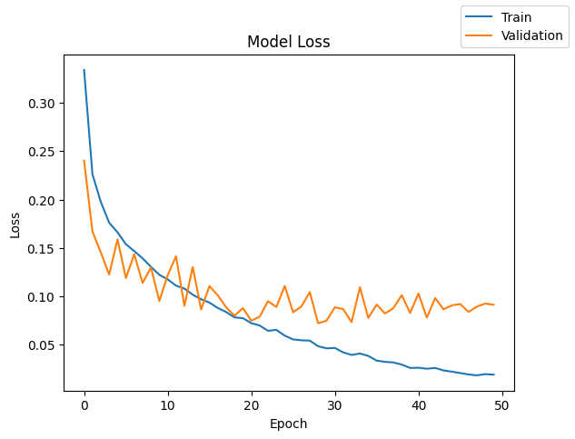

```python
plot(history_4, 'loss')
```

- Training loss continues to decrease steadily, while validation loss stops improving after ~15–20 epochs and begins fluctuating.
- The widening gap between training and validation loss indicates the model is starting to overfit the training data.
- Early stopping, stronger regularization, or reduced model complexity may help improve generalization performance.

```python
model_4_train_perf = model_performance_classification(model_4, X_train, y_train)
model_4_train_perf
```

```
438/438 ━━━━━━━━━━━━━━━━━━━━ 1s 1ms/step
```

|  | Accuracy | Recall | Precision | F1 Score |
| --- | --- | --- | --- | --- |
| 0 | 0.996429 | 0.998109 | 0.96977 | 0.983467 |

```python
model_4_val_perf = model_performance_classification(model_4, X_val, y_val)
model_4_val_perf
```

```
188/188 ━━━━━━━━━━━━━━━━━━━━ 0s 1ms/step
```

|  | Accuracy | Recall | Precision | F1 Score |
| --- | --- | --- | --- | --- |
| 0 | 0.983833 | 0.932084 | 0.916806 | 0.924287 |

```python
y_train_pred_4 = model_4.predict(X_train)
y_val_pred_4 = model_4.predict(X_val)
```

```
438/438 ━━━━━━━━━━━━━━━━━━━━ 0s 849us/step
188/188 ━━━━━━━━━━━━━━━━━━━━ 0s 942us/step
```

```python
print("Classification Report - Train data Model_4", end="\n\n")
cr_train_model_4 = classification_report(y_train, y_train_pred_4 > 0.5)
print(cr_train_model_4)
```

```
Classification Report - Train data Model_4

              precision    recall  f1-score   support

         0.0       1.00      1.00      1.00     13223
         1.0       0.97      1.00      0.99       777

    accuracy                           1.00     14000
   macro avg       0.99      1.00      0.99     14000
weighted avg       1.00      1.00      1.00     14000
```

```python
print("Classification Report - Validation data Model_4", end="\n\n")
cr_val_model_4 = classification_report(y_val, y_val_pred_4 > 0.5)
print(cr_val_model_4)
```

```
Classification Report - Validation data Model_4

              precision    recall  f1-score   support

         0.0       0.99      0.99      0.99      5667
         1.0       0.89      0.88      0.88       333

    accuracy                           0.99      6000
   macro avg       0.94      0.94      0.94      6000
weighted avg       0.99      0.99      0.99      6000
```

Model 4, employing the Adam optimizer, exhibited significant overfitting on the validation set, indicated by diverging loss curves. While achieving a validation F1-score of 0.92, its reduced generalizability makes it less suitable than Model 3 for reliable failure prediction.

```python
# clears the current Keras session, resetting all layers and models previously created, freeing up memory and resources.
tf.keras.backend.clear_session()
```

```python
model_5 = Sequential()
model_5.add(Dense(256, activation="relu", input_dim=X_train.shape[1]))
model_5.add(Dropout(0.5))
model_5.add(Dense(128, activation="relu"))
#model_5.add(Dropout(0.2))
model_5.add(Dense(64, activation="relu"))
model_5.add(Dense(1, activation="sigmoid"))
```

```python
model_5.summary()
```

```
Model: "sequential"
```

```
┏━━━━━━━━━━━━━━━━━━━━━━━━━━━━━━━━━┳━━━━━━━━━━━━━━━━━━━━━━━━┳━━━━━━━━━━━━━━━┓
┃ Layer (type)                    ┃ Output Shape           ┃       Param # ┃
┡━━━━━━━━━━━━━━━━━━━━━━━━━━━━━━━━━╇━━━━━━━━━━━━━━━━━━━━━━━━╇━━━━━━━━━━━━━━━┩
│ dense (Dense)                   │ (None, 256)            │        10,496 │
├─────────────────────────────────┼────────────────────────┼───────────────┤
│ dropout (Dropout)               │ (None, 256)            │             0 │
├─────────────────────────────────┼────────────────────────┼───────────────┤
│ dense_1 (Dense)                 │ (None, 128)            │        32,896 │
├─────────────────────────────────┼────────────────────────┼───────────────┤
│ dense_2 (Dense)                 │ (None, 64)             │         8,256 │
├─────────────────────────────────┼────────────────────────┼───────────────┤
│ dense_3 (Dense)                 │ (None, 1)              │            65 │
└─────────────────────────────────┴────────────────────────┴───────────────┘
```

```
 Total params: 51,713 (202.00 KB)
```

```
 Trainable params: 51,713 (202.00 KB)
```

```
 Non-trainable params: 0 (0.00 B)
```

Compiling Model 5, which is optimized for binary failure prediction, prioritizes 'Recall' to minimize undetected generator failures, aligning with our predictive maintenance goals.

```python
optimizer_5 = tf.keras.optimizers.Adam(0.0001) # Using Adam optimizer
model_5.compile(loss='binary_crossentropy', optimizer=optimizer_5, metrics=['Recall'])
```

```python
start_5 = time.time()
history_5 = model_5.fit(X_train, y_train, validation_data=(X_val, y_val), batch_size=batch_size, epochs=epochs, class_weight=class_weights_dict)
end_5 = time.time()
```

```
438/438 ━━━━━━━━━━━━━━━━━━━━ 2s 3ms/step - Recall: 0.7568 - loss: 0.4819 - val_Recall: 0.8228 - val_loss: 0.2691
438/438 ━━━━━━━━━━━━━━━━━━━━ 1s 3ms/step - Recall: 0.8610 - loss: 0.3550 - val_Recall: 0.8649 - val_loss: 0.2104
438/438 ━━━━━━━━━━━━━━━━━━━━ 1s 3ms/step - Recall: 0.8816 - loss: 0.3095 - val_Recall: 0.8498 - val_loss: 0.1613
438/438 ━━━━━━━━━━━━━━━━━━━━ 1s 3ms/step - Recall: 0.8906 - loss: 0.2915 - val_Recall: 0.8619 - val_loss: 0.1577
438/438 ━━━━━━━━━━━━━━━━━━━━ 1s 3ms/step - Recall: 0.8958 - loss: 0.2702 - val_Recall: 0.8739 - val_loss: 0.1595
438/438 ━━━━━━━━━━━━━━━━━━━━ 1s 3ms/step - Recall: 0.8932 - loss: 0.2534 - val_Recall: 0.8739 - val_loss: 0.1460
438/438 ━━━━━━━━━━━━━━━━━━━━ 2s 4ms/step - Recall: 0.8893 - loss: 0.2535 - val_Recall: 0.8739 - val_loss: 0.1376
438/438 ━━━━━━━━━━━━━━━━━━━━ 1s 3ms/step - Recall: 0.9060 - loss: 0.2373 - val_Recall: 0.8589 - val_loss: 0.1257
438/438 ━━━━━━━━━━━━━━━━━━━━ 1s 3ms/step - Recall: 0.8880 - loss: 0.2344 - val_Recall: 0.8829 - val_loss: 0.1610
438/438 ━━━━━━━━━━━━━━━━━━━━ 1s 3ms/step - Recall: 0.9048 - loss: 0.2133 - val_Recall: 0.8709 - val_loss: 0.1354
438/438 ━━━━━━━━━━━━━━━━━━━━ 1s 3ms/step - Recall: 0.9048 - loss: 0.2071 - val_Recall: 0.8739 - val_loss: 0.1220
438/438 ━━━━━━━━━━━━━━━━━━━━ 1s 3ms/step - Recall: 0.9009 - loss: 0.2083 - val_Recall: 0.8799 - val_loss: 0.1619
438/438 ━━━━━━━━━━━━━━━━━━━━ 1s 3ms/step - Recall: 0.8996 - loss: 0.2108 - val_Recall: 0.8799 - val_loss: 0.1309
438/438 ━━━━━━━━━━━━━━━━━━━━ 1s 3ms/step - Recall: 0.8996 - loss: 0.1997 - val_Recall: 0.8769 - val_loss: 0.1351
438/438 ━━━━━━━━━━━━━━━━━━━━ 1s 3ms/step - Recall: 0.9035 - loss: 0.1942 - val_Recall: 0.8769 - val_loss: 0.1415
438/438 ━━━━━━━━━━━━━━━━━━━━ 2s 4ms/step - Recall: 0.9086 - loss: 0.1873 - val_Recall: 0.8769 - val_loss: 0.1220
438/438 ━━━━━━━━━━━━━━━━━━━━ 1s 3ms/step - Recall: 0.9151 - loss: 0.1863 - val_Recall: 0.8769 - val_loss: 0.1094
438/438 ━━━━━━━━━━━━━━━━━━━━ 1s 3ms/step - Recall: 0.9099 - loss: 0.1857 - val_Recall: 0.8739 - val_loss: 0.1172
438/438 ━━━━━━━━━━━━━━━━━━━━ 1s 3ms/step - Recall: 0.9073 - loss: 0.1852 - val_Recall: 0.8799 - val_loss: 0.1441
438/438 ━━━━━━━━━━━━━━━━━━━━ 1s 2ms/step - Recall: 0.9163 - loss: 0.1744 - val_Recall: 0.8709 - val_loss: 0.1301
438/438 ━━━━━━━━━━━━━━━━━━━━ 1s 3ms/step - Recall: 0.9112 - loss: 0.1793 - val_Recall: 0.8739 - val_loss: 0.1174
438/438 ━━━━━━━━━━━━━━━━━━━━ 1s 3ms/step - Recall: 0.9060 - loss: 0.1788 - val_Recall: 0.8739 - val_loss: 0.1128
438/438 ━━━━━━━━━━━━━━━━━━━━ 1s 2ms/step - Recall: 0.9086 - loss: 0.1729 - val_Recall: 0.8769 - val_loss: 0.1322
438/438 ━━━━━━━━━━━━━━━━━━━━ 1s 2ms/step - Recall: 0.9176 - loss: 0.1686 - val_Recall: 0.8769 - val_loss: 0.1084
438/438 ━━━━━━━━━━━━━━━━━━━━ 2s 4ms/step - Recall: 0.9189 - loss: 0.1608 - val_Recall: 0.8859 - val_loss: 0.1433
438/438 ━━━━━━━━━━━━━━━━━━━━ 2s 4ms/step - Recall: 0.9151 - loss: 0.1670 - val_Recall: 0.8829 - val_loss: 0.1340
438/438 ━━━━━━━━━━━━━━━━━━━━ 1s 3ms/step - Recall: 0.9215 - loss: 0.1659 - val_Recall: 0.8889 - val_loss: 0.1507
438/438 ━━━━━━━━━━━━━━━━━━━━ 1s 3ms/step - Recall: 0.9151 - loss: 0.1575 - val_Recall: 0.8889 - val_loss: 0.1389
438/438 ━━━━━━━━━━━━━━━━━━━━ 1s 3ms/step - Recall: 0.9125 - loss: 0.1593 - val_Recall: 0.8769 - val_loss: 0.1176
438/438 ━━━━━━━━━━━━━━━━━━━━ 1s 3ms/step - Recall: 0.9241 - loss: 0.1566 - val_Recall: 0.8769 - val_loss: 0.0995
438/438 ━━━━━━━━━━━━━━━━━━━━ 1s 3ms/step - Recall: 0.9202 - loss: 0.1583 - val_Recall: 0.8799 - val_loss: 0.1223
438/438 ━━━━━━━━━━━━━━━━━━━━ 1s 3ms/step - Recall: 0.9163 - loss: 0.1551 - val_Recall: 0.8859 - val_loss: 0.1144
438/438 ━━━━━━━━━━━━━━━━━━━━ 1s 3ms/step - Recall: 0.9151 - loss: 0.1645 - val_Recall: 0.8889 - val_loss: 0.1439
438/438 ━━━━━━━━━━━━━━━━━━━━ 1s 3ms/step - Recall: 0.9138 - loss: 0.1562 - val_Recall: 0.8859 - val_loss: 0.1151
438/438 ━━━━━━━━━━━━━━━━━━━━ 2s 4ms/step - Recall: 0.9241 - loss: 0.1466 - val_Recall: 0.8889 - val_loss: 0.1229
438/438 ━━━━━━━━━━━━━━━━━━━━ 1s 3ms/step - Recall: 0.9151 - loss: 0.1531 - val_Recall: 0.8859 - val_loss: 0.1207
438/438 ━━━━━━━━━━━━━━━━━━━━ 1s 3ms/step - Recall: 0.9151 - loss: 0.1508 - val_Recall: 0.8859 - val_loss: 0.1208
438/438 ━━━━━━━━━━━━━━━━━━━━ 1s 3ms/step - Recall: 0.9176 - loss: 0.1487 - val_Recall: 0.8799 - val_loss: 0.0958
438/438 ━━━━━━━━━━━━━━━━━━━━ 1s 3ms/step - Recall: 0.9215 - loss: 0.1499 - val_Recall: 0.8799 - val_loss: 0.1230
438/438 ━━━━━━━━━━━━━━━━━━━━ 1s 3ms/step - Recall: 0.9151 - loss: 0.1542 - val_Recall: 0.8829 - val_loss: 0.1270
438/438 ━━━━━━━━━━━━━━━━━━━━ 1s 3ms/step - Recall: 0.9215 - loss: 0.1476 - val_Recall: 0.8829 - val_loss: 0.1114
438/438 ━━━━━━━━━━━━━━━━━━━━ 1s 3ms/step - Recall: 0.9254 - loss: 0.1416 - val_Recall: 0.8889 - val_loss: 0.1275
438/438 ━━━━━━━━━━━━━━━━━━━━ 1s 3ms/step - Recall: 0.9254 - loss: 0.1392 - val_Recall: 0.8769 - val_loss: 0.0960
438/438 ━━━━━━━━━━━━━━━━━━━━ 2s 4ms/step - Recall: 0.9228 - loss: 0.1374 - val_Recall: 0.8889 - val_loss: 0.1110
438/438 ━━━━━━━━━━━━━━━━━━━━ 1s 3ms/step - Recall: 0.9241 - loss: 0.1401 - val_Recall: 0.8859 - val_loss: 0.1012
438/438 ━━━━━━━━━━━━━━━━━━━━ 1s 3ms/step - Recall: 0.9228 - loss: 0.1401 - val_Recall: 0.8799 - val_loss: 0.0997
438/438 ━━━━━━━━━━━━━━━━━━━━ 1s 3ms/step - Recall: 0.9176 - loss: 0.1475 - val_Recall: 0.8829 - val_loss: 0.1060
438/438 ━━━━━━━━━━━━━━━━━━━━ 1s 3ms/step - Recall: 0.9266 - loss: 0.1428 - val_Recall: 0.8769 - val_loss: 0.1151
438/438 ━━━━━━━━━━━━━━━━━━━━ 1s 3ms/step - Recall: 0.9279 - loss: 0.1333 - val_Recall: 0.8799 - val_loss: 0.1033
438/438 ━━━━━━━━━━━━━━━━━━━━ 1s 3ms/step - Recall: 0.9228 - loss: 0.1381 - val_Recall: 0.8859 - val_loss: 0.1139
```

```python
print("Time taken in seconds ", end_5 - start_5)
```

```
Time taken in seconds  65.0025224685669
```

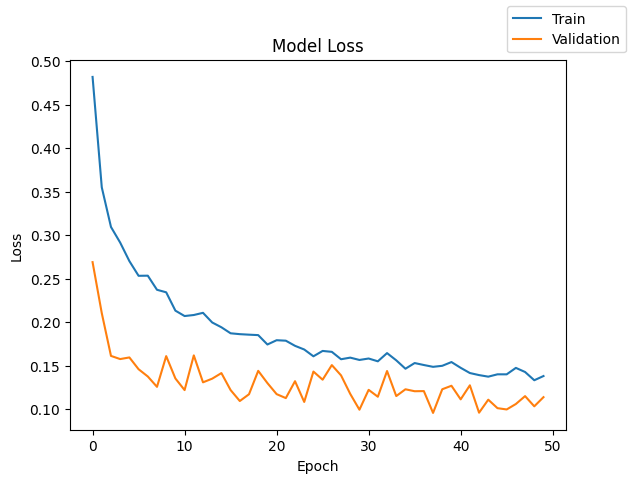

```python
plot(history_5, 'loss')
```

```python
model_5_train_perf = model_performance_classification(model_5, X_train, y_train)
model_5_train_perf
```

```
438/438 ━━━━━━━━━━━━━━━━━━━━ 0s 973us/step
```

|  | Accuracy | Recall | Precision | F1 Score |
| --- | --- | --- | --- | --- |
| 0 | 0.9905 | 0.964686 | 0.94687 | 0.955579 |

```python
model_5_val_perf = model_performance_classification(model_5, X_val, y_val)
model_5_val_perf
```

```
188/188 ━━━━━━━━━━━━━━━━━━━━ 0s 910us/step
```

|  | Accuracy | Recall | Precision | F1 Score |
| --- | --- | --- | --- | --- |
| 0 | 0.987 | 0.939414 | 0.936945 | 0.938175 |

Generating predictions for training and validation data to assess Model 5's performance.

```python
y_train_pred_5 = model_5.predict(X_train)
y_val_pred_5 = model_5.predict(X_val)
```

```
438/438 ━━━━━━━━━━━━━━━━━━━━ 1s 2ms/step
188/188 ━━━━━━━━━━━━━━━━━━━━ 0s 896us/step
```

Reviewing the training data performance report for Model 5, focusing on key metrics like Recall, Precision, and F1-Score.

```python
print("Classification Report - Train data Model_5", end="\n\n")
cr_train_model_5 = classification_report(y_train, y_train_pred_5 > 0.5)
print(cr_train_model_5)
```

```
Classification Report - Train data Model_5

              precision    recall  f1-score   support

         0.0       1.00      0.99      0.99     13223
         1.0       0.90      0.94      0.92       777

    accuracy                           0.99     14000
   macro avg       0.95      0.96      0.96     14000
weighted avg       0.99      0.99      0.99     14000
```

Analyzing Model 5's performance on unseen validation data using a detailed classification report. This helps confirm its ability to generalize, with a focus on 'Recall' to ensure high failure detection.

```python
print("Classification Report - Validation data Model_5", end="\n\n")
cr_val_model_5 = classification_report(y_val, y_val_pred_5 > 0.5)
print(cr_val_model_5)
```

```
Classification Report - Validation data Model_5

              precision    recall  f1-score   support

         0.0       0.99      0.99      0.99      5667
         1.0       0.88      0.89      0.88       333

    accuracy                           0.99      6000
   macro avg       0.94      0.94      0.94      6000
weighted avg       0.99      0.99      0.99      6000
```

Model 5, with class weights and Adam optimizer, achieves a validation Recall of 0.939 and an F1-score of 0.938. This shows improved Recall over Model 1, slightly higher Recall but lower F1-score than Model 2, comparable performance to Model 3, and significantly outperforms Model 4 in generalizability and metrics.

### Model 6: Using Adam Optimizer and Dropout with balanced class weights

```python
# clears the current Keras session, resetting all layers and models previously created, freeing up memory and resources.
tf.keras.backend.clear_session()
```

```python
from sklearn.utils import class_weight
import numpy as np

# Calculate class weights for imbalanced dataset
class_weights = class_weight.compute_class_weight(
    class_weight='balanced',
    classes=np.unique(y_train),
    y=y_train
)

# Create a dictionary mapping class indices to their respective class weights
class_weights_dict = dict(enumerate(class_weights))
print("Class Weights:", class_weights_dict)
```

```
Class Weights: {0: np.float64(0.5293806246691372), 1: np.float64(9.00900900900901)}
```

```python
#Initializing the neural network for Model 6
model_6 = Sequential()
model_6.add(Dense(256, activation="relu", input_dim=X_train.shape[1]))
model_6.add(Dropout(0.5))
model_6.add(Dense(128, activation="relu"))
#model_6.add(Dropout(0.2))
model_6.add(Dense(64, activation="relu"))
#model_6.add(Dense(32, activation="relu"))
model_6.add(Dense(1, activation="sigmoid"))
```

```python
model_6.summary()
```

```
Model: "sequential"
```

```
┏━━━━━━━━━━━━━━━━━━━━━━━━━━━━━━━━━┳━━━━━━━━━━━━━━━━━━━━━━━━┳━━━━━━━━━━━━━━━┓
┃ Layer (type)                    ┃ Output Shape           ┃       Param # ┃
┡━━━━━━━━━━━━━━━━━━━━━━━━━━━━━━━━━╇━━━━━━━━━━━━━━━━━━━━━━━━╇━━━━━━━━━━━━━━━┩
│ dense (Dense)                   │ (None, 256)            │        10,496 │
├─────────────────────────────────┼────────────────────────┼───────────────┤
│ dropout (Dropout)               │ (None, 256)            │             0 │
├─────────────────────────────────┼────────────────────────┼───────────────┤
│ dense_1 (Dense)                 │ (None, 128)            │        32,896 │
├─────────────────────────────────┼────────────────────────┼───────────────┤
│ dense_2 (Dense)                 │ (None, 64)             │         8,256 │
├─────────────────────────────────┼────────────────────────┼───────────────┤
│ dense_3 (Dense)                 │ (None, 1)              │            65 │
└─────────────────────────────────┴────────────────────────┴───────────────┘
```

```
 Total params: 51,713 (202.00 KB)
```

```
 Trainable params: 51,713 (202.00 KB)
```

```
 Non-trainable params: 0 (0.00 B)
```

Compiling Model 6, optimized for binary failure prediction, with 'Recall' as the primary metric to minimize undetected generator failures.

```python
optimizer_6 = tf.keras.optimizers.Adam(0.0001) # Using Adam optimizer
model_6.compile(loss='binary_crossentropy', optimizer=optimizer_6, metrics=['Recall'])
```

```python
start_6 = time.time()
history_6 = model_6.fit(X_train, y_train, validation_data=(X_val, y_val), batch_size=batch_size, epochs=epochs, class_weight=class_weights_dict)
end_6 = time.time()
```

```
438/438 ━━━━━━━━━━━━━━━━━━━━ 3s 3ms/step - Recall: 0.7220 - loss: 0.5117 - val_Recall: 0.8589 - val_loss: 0.3324
438/438 ━━━━━━━━━━━━━━━━━━━━ 1s 3ms/step - Recall: 0.8610 - loss: 0.3531 - val_Recall: 0.8679 - val_loss: 0.2332
438/438 ━━━━━━━━━━━━━━━━━━━━ 1s 3ms/step - Recall: 0.8919 - loss: 0.3032 - val_Recall: 0.8799 - val_loss: 0.1901
438/438 ━━━━━━━━━━━━━━━━━━━━ 1s 3ms/step - Recall: 0.8983 - loss: 0.2760 - val_Recall: 0.8649 - val_loss: 0.1539
438/438 ━━━━━━━━━━━━━━━━━━━━ 1s 3ms/step - Recall: 0.8906 - loss: 0.2754 - val_Recall: 0.8769 - val_loss: 0.1619
438/438 ━━━━━━━━━━━━━━━━━━━━ 1s 2ms/step - Recall: 0.9022 - loss: 0.2493 - val_Recall: 0.8799 - val_loss: 0.1764
438/438 ━━━━━━━━━━━━━━━━━━━━ 1s 2ms/step - Recall: 0.8983 - loss: 0.2394 - val_Recall: 0.8829 - val_loss: 0.1587
438/438 ━━━━━━━━━━━━━━━━━━━━ 1s 2ms/step - Recall: 0.9022 - loss: 0.2358 - val_Recall: 0.8769 - val_loss: 0.1343
438/438 ━━━━━━━━━━━━━━━━━━━━ 1s 3ms/step - Recall: 0.9073 - loss: 0.2237 - val_Recall: 0.8799 - val_loss: 0.1362
438/438 ━━━━━━━━━━━━━━━━━━━━ 2s 4ms/step - Recall: 0.9009 - loss: 0.2209 - val_Recall: 0.8829 - val_loss: 0.1514
438/438 ━━━━━━━━━━━━━━━━━━━━ 2s 2ms/step - Recall: 0.9009 - loss: 0.2201 - val_Recall: 0.8769 - val_loss: 0.1337
438/438 ━━━━━━━━━━━━━━━━━━━━ 1s 3ms/step - Recall: 0.9112 - loss: 0.2027 - val_Recall: 0.8769 - val_loss: 0.1260
438/438 ━━━━━━━━━━━━━━━━━━━━ 1s 3ms/step - Recall: 0.9086 - loss: 0.2095 - val_Recall: 0.8859 - val_loss: 0.1334
438/438 ━━━━━━━━━━━━━━━━━━━━ 1s 3ms/step - Recall: 0.9048 - loss: 0.2029 - val_Recall: 0.8829 - val_loss: 0.1362
438/438 ━━━━━━━━━━━━━━━━━━━━ 1s 3ms/step - Recall: 0.9086 - loss: 0.1909 - val_Recall: 0.8799 - val_loss: 0.1374
438/438 ━━━━━━━━━━━━━━━━━━━━ 1s 2ms/step - Recall: 0.9086 - loss: 0.1869 - val_Recall: 0.8859 - val_loss: 0.1289
438/438 ━━━━━━━━━━━━━━━━━━━━ 1s 2ms/step - Recall: 0.9112 - loss: 0.1921 - val_Recall: 0.8889 - val_loss: 0.1543
438/438 ━━━━━━━━━━━━━━━━━━━━ 1s 3ms/step - Recall: 0.9086 - loss: 0.1834 - val_Recall: 0.8889 - val_loss: 0.1186
438/438 ━━━━━━━━━━━━━━━━━━━━ 2s 4ms/step - Recall: 0.9060 - loss: 0.1786 - val_Recall: 0.8859 - val_loss: 0.1307
438/438 ━━━━━━━━━━━━━━━━━━━━ 1s 3ms/step - Recall: 0.9086 - loss: 0.1838 - val_Recall: 0.8889 - val_loss: 0.1497
438/438 ━━━━━━━━━━━━━━━━━━━━ 1s 3ms/step - Recall: 0.9163 - loss: 0.1769 - val_Recall: 0.8859 - val_loss: 0.1255
438/438 ━━━━━━━━━━━━━━━━━━━━ 1s 3ms/step - Recall: 0.9099 - loss: 0.1787 - val_Recall: 0.8889 - val_loss: 0.1400
438/438 ━━━━━━━━━━━━━━━━━━━━ 1s 2ms/step - Recall: 0.9163 - loss: 0.1640 - val_Recall: 0.8889 - val_loss: 0.1223
438/438 ━━━━━━━━━━━━━━━━━━━━ 1s 3ms/step - Recall: 0.9202 - loss: 0.1699 - val_Recall: 0.8889 - val_loss: 0.1358
438/438 ━━━━━━━━━━━━━━━━━━━━ 1s 3ms/step - Recall: 0.9138 - loss: 0.1574 - val_Recall: 0.8859 - val_loss: 0.1127
438/438 ━━━━━━━━━━━━━━━━━━━━ 1s 3ms/step - Recall: 0.9151 - loss: 0.1656 - val_Recall: 0.8769 - val_loss: 0.1172
438/438 ━━━━━━━━━━━━━━━━━━━━ 1s 3ms/step - Recall: 0.9163 - loss: 0.1600 - val_Recall: 0.8859 - val_loss: 0.0974
438/438 ━━━━━━━━━━━━━━━━━━━━ 2s 4ms/step - Recall: 0.9099 - loss: 0.1608 - val_Recall: 0.8919 - val_loss: 0.1308
438/438 ━━━━━━━━━━━━━━━━━━━━ 1s 3ms/step - Recall: 0.9189 - loss: 0.1545 - val_Recall: 0.8889 - val_loss: 0.1100
438/438 ━━━━━━━━━━━━━━━━━━━━ 2s 3ms/step - Recall: 0.9228 - loss: 0.1518 - val_Recall: 0.8859 - val_loss: 0.1006
438/438 ━━━━━━━━━━━━━━━━━━━━ 1s 2ms/step - Recall: 0.9189 - loss: 0.1561 - val_Recall: 0.8919 - val_loss: 0.1271
438/438 ━━━━━━━━━━━━━━━━━━━━ 1s 3ms/step - Recall: 0.9228 - loss: 0.1497 - val_Recall: 0.8919 - val_loss: 0.1253
438/438 ━━━━━━━━━━━━━━━━━━━━ 1s 3ms/step - Recall: 0.9266 - loss: 0.1477 - val_Recall: 0.8919 - val_loss: 0.1051
438/438 ━━━━━━━━━━━━━━━━━━━━ 1s 3ms/step - Recall: 0.9215 - loss: 0.1508 - val_Recall: 0.8919 - val_loss: 0.1263
438/438 ━━━━━━━━━━━━━━━━━━━━ 1s 3ms/step - Recall: 0.9189 - loss: 0.1484 - val_Recall: 0.8919 - val_loss: 0.1058
438/438 ━━━━━━━━━━━━━━━━━━━━ 2s 4ms/step - Recall: 0.9189 - loss: 0.1444 - val_Recall: 0.8889 - val_loss: 0.1053
438/438 ━━━━━━━━━━━━━━━━━━━━ 2s 3ms/step - Recall: 0.9189 - loss: 0.1466 - val_Recall: 0.8949 - val_loss: 0.1182
438/438 ━━━━━━━━━━━━━━━━━━━━ 1s 3ms/step - Recall: 0.9292 - loss: 0.1373 - val_Recall: 0.8829 - val_loss: 0.0847
438/438 ━━━━━━━━━━━━━━━━━━━━ 1s 3ms/step - Recall: 0.9241 - loss: 0.1451 - val_Recall: 0.8919 - val_loss: 0.1107
438/438 ━━━━━━━━━━━━━━━━━━━━ 1s 3ms/step - Recall: 0.9215 - loss: 0.1469 - val_Recall: 0.8829 - val_loss: 0.1097
438/438 ━━━━━━━━━━━━━━━━━━━━ 1s 3ms/step - Recall: 0.9189 - loss: 0.1487 - val_Recall: 0.8859 - val_loss: 0.0958
438/438 ━━━━━━━━━━━━━━━━━━━━ 1s 3ms/step - Recall: 0.9176 - loss: 0.1511 - val_Recall: 0.8889 - val_loss: 0.1017
438/438 ━━━━━━━━━━━━━━━━━━━━ 1s 3ms/step - Recall: 0.9202 - loss: 0.1364 - val_Recall: 0.8889 - val_loss: 0.1048
438/438 ━━━━━━━━━━━━━━━━━━━━ 1s 3ms/step - Recall: 0.9228 - loss: 0.1462 - val_Recall: 0.8889 - val_loss: 0.1096
438/438 ━━━━━━━━━━━━━━━━━━━━ 2s 4ms/step - Recall: 0.9318 - loss: 0.1291 - val_Recall: 0.8889 - val_loss: 0.1062
438/438 ━━━━━━━━━━━━━━━━━━━━ 1s 3ms/step - Recall: 0.9266 - loss: 0.1347 - val_Recall: 0.8949 - val_loss: 0.1288
438/438 ━━━━━━━━━━━━━━━━━━━━ 1s 3ms/step - Recall: 0.9266 - loss: 0.1295 - val_Recall: 0.8919 - val_loss: 0.0984
438/438 ━━━━━━━━━━━━━━━━━━━━ 1s 3ms/step - Recall: 0.9228 - loss: 0.1334 - val_Recall: 0.8889 - val_loss: 0.1165
438/438 ━━━━━━━━━━━━━━━━━━━━ 1s 3ms/step - Recall: 0.9241 - loss: 0.1335 - val_Recall: 0.8889 - val_loss: 0.1199
438/438 ━━━━━━━━━━━━━━━━━━━━ 1s 3ms/step - Recall: 0.9266 - loss: 0.1344 - val_Recall: 0.8919 - val_loss: 0.1051
```

```python
print("Time taken in seconds ", end_6 - start_6)
```

```
Time taken in seconds  66.0248236656189
```

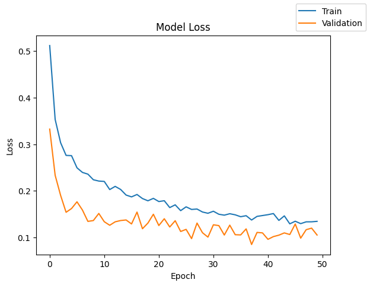

```python
plot(history_6, 'loss')
```

- Both training and validation loss decline consistently, showing the model is learning stable patterns from the data.
- Validation loss remains lower and relatively close to training loss, suggesting good generalization with limited overfitting.
- The gradual flattening of both curves after ~30 epochs indicates the model is approaching convergence and performance gains are stabilizing. We could potentially reduce epochs to save run time.

```python
model_6_train_perf = model_performance_classification(model_6, X_train, y_train)
model_6_train_perf
```

```
438/438 ━━━━━━━━━━━━━━━━━━━━ 0s 964us/step
```

|  | Accuracy | Recall | Precision | F1 Score |
| --- | --- | --- | --- | --- |
| 0 | 0.990071 | 0.962643 | 0.944904 | 0.953575 |

```python
model_6_val_perf = model_performance_classification(model_6, X_val, y_val)
model_6_val_perf
```

```
188/188 ━━━━━━━━━━━━━━━━━━━━ 0s 903us/step
```

|  | Accuracy | Recall | Precision | F1 Score |
| --- | --- | --- | --- | --- |
| 0 | 0.986 | 0.941711 | 0.927252 | 0.934344 |

Generating predictions for training and validation data to assess Model 6's performance.

```python
y_train_pred_6 = model_6.predict(X_train)
y_val_pred_6 = model_6.predict(X_val)
```

```
438/438 ━━━━━━━━━━━━━━━━━━━━ 1s 1ms/step
188/188 ━━━━━━━━━━━━━━━━━━━━ 0s 1ms/step
```

Reviewing the training data performance report for Model 6, focusing on key metrics like Recall, Precision, and F1-Score.

```python
print("Classification Report - Train data Model_6", end="\n\n")
cr_train_model_6 = classification_report(y_train, y_train_pred_6 > 0.5)
print(cr_train_model_6)
```

```
Classification Report - Train data Model_6

              precision    recall  f1-score   support

         0.0       1.00      0.99      0.99     13223
         1.0       0.89      0.93      0.91       777

    accuracy                           0.99     14000
   macro avg       0.94      0.96      0.95     14000
weighted avg       0.99      0.99      0.99     14000
```

Analyzing Model 6's performance on unseen validation data using a detailed classification report. This helps confirm its ability to generalize, with a focus on 'Recall' to ensure high failure detection.

```python
print("Classification Report - Validation data Model_6", end="\n\n")
cr_val_model_6 = classification_report(y_val, y_val_pred_6 > 0.5)
print(cr_val_model_6)
```

```
Classification Report - Validation data Model_6

              precision    recall  f1-score   support

         0.0       0.99      0.99      0.99      5667
         1.0       0.86      0.89      0.88       333

    accuracy                           0.99      6000
   macro avg       0.93      0.94      0.93      6000
weighted avg       0.99      0.99      0.99      6000
```

# **Model Performance Comparison and Final Model Selection**

Now, in order to select the final model, we will compare the performances of all the models for the training and validation sets.

```python
# training performance comparison

models_train_comp_df = pd.concat(
    [
        model_0_train_perf.T,
        model_1_train_perf.T,
        model_2_train_perf.T,
        model_3_train_perf.T,
        model_4_train_perf.T,
        model_5_train_perf.T,
        model_6_train_perf.T

    ],
    axis=1,
)
models_train_comp_df.columns = [
    "Model 0",
    "Model 1",
    "Model 2",
    "Model 3",
    "Model 4",
    "Model 5",
    "Model 6"
]
print("Training set performance comparison:")
models_train_comp_df
```

```
Training set performance comparison:
```

|  | Model 0 | Model 1 | Model 2 | Model 3 | Model 4 | Model 5 | Model 6 |
| --- | --- | --- | --- | --- | --- | --- | --- |
| Accuracy | 0.990929 | 0.994643 | 0.994000 | 0.988857 | 0.996429 | 0.990500 | 0.990071 |
| Recall | 0.926755 | 0.954766 | 0.950791 | 0.960183 | 0.998109 | 0.964686 | 0.962643 |
| Precision | 0.985434 | 0.993855 | 0.991499 | 0.936974 | 0.969770 | 0.946870 | 0.944904 |
| F1 Score | 0.953965 | 0.973401 | 0.970152 | 0.948235 | 0.983467 | 0.955579 | 0.953575 |

Model 4 shows the highest Recall (0.998) and F1 Score (0.983) on the training set, suggesting it fits the training data exceptionally well. Models 1, 3, 5, and 6 also demonstrate strong training performance, with Recall values ranging from 0.95 to 0.96 and F1 Scores around 0.95-0.97. Model 0 has the lowest training Recall (0.927) among all models.

```python
# Validation performance comparison

models_val_comp_df = pd.concat(
    [
        model_0_val_perf.T,
        model_1_val_perf.T,
        model_2_val_perf.T,
        model_3_val_perf.T,
        model_4_val_perf.T,
        model_5_val_perf.T,
        model_6_val_perf.T

    ],
    axis=1,
)
models_val_comp_df.columns = [
    "Model 0",
    "Model 1",
    "Model 2",
    "Model 3",
    "Model 4",
    "Model 5",
    "Model 6"
]
print("Validation set performance comparison:")
models_val_comp_df
```

```
Validation set performance comparison:
```

|  | Model 0 | Model 1 | Model 2 | Model 3 | Model 4 | Model 5 | Model 6 |
| --- | --- | --- | --- | --- | --- | --- | --- |
| Accuracy | 0.989000 | 0.989500 | 0.992000 | 0.986667 | 0.983833 | 0.987000 | 0.986000 |
| Recall | 0.913620 | 0.925191 | 0.934994 | 0.942064 | 0.932084 | 0.939414 | 0.941711 |
| Precision | 0.979224 | 0.972213 | 0.987757 | 0.932303 | 0.916806 | 0.936945 | 0.927252 |
| F1 Score | 0.943703 | 0.947309 | 0.959673 | 0.937121 | 0.924287 | 0.938175 | 0.934344 |

### Final Model Recommendation

Considering the primary objective to maximize `Recall` (to minimize undetected failures, which lead to expensive replacements) and also taking into account the `F1-score` for a balanced performance, **Model 3** is the recommended model.

**Reasoning:**

- **Highest Recall (0.942):** Model 3 achieved the highest Recall on the validation set among all models (0.942). This is crucial for ReneWind, as it directly addresses the most expensive mistake: missing actual generator failures. Model 6 had a very similar Recall (0.941) and Model 5 had a Recall of 0.939, but Model 3 slightly edges them out on this critical metric.
- **Strong F1-score (0.937):** Along with the highest Recall, Model 3 also demonstrates a strong F1-score of 0.937. This indicates a good balance between Precision and Recall, ensuring that while we are catching most true failures, we are not generating an excessive number of false alarms (inspections).
- **Robustness to Overfitting:** Unlike Model 4, which showed signs of significant overfitting despite a decent validation F1-score, Model 3, with its use of class weights and dropout, maintained a healthy relationship between training and validation losses, suggesting good generalization capabilities.
- **Efficient Training Time:** Model 3's training time was approximately 53 seconds, which is competitive and more efficient than models like Model 5 (65 seconds) and Model 6 (66 seconds) that offered comparable or slightly lower performance on the key metrics.

```python
# best_model = model_0 ## Uncomment this line in case the best model is model_0
# best_model = model_1 ## Uncomment this line in case the best model is model_1
# best_model = model_2 ## Uncomment this line in case the best model is model_2
best_model = model_3 ## Uncomment this line in case the best model is model_3
# best_model = model_4 ## Uncomment this line in case the best model is model_4
# best_model = model_5 ## Uncomment this line in case the best model is model_5
# best_model = model_6 ## Uncomment this line in case the best model is model_6
```

```python
# Test set performance for the best model
best_model_test_perf = model_performance_classification(best_model,X_test,y_test)
best_model_test_perf
```

```
157/157 ━━━━━━━━━━━━━━━━━━━━ 0s 2ms/step
```

|  | Accuracy | Recall | Precision | F1 Score |
| --- | --- | --- | --- | --- |
| 0 | 0.986 | 0.937568 | 0.931814 | 0.93467 |

The model achieved strong overall performance with 98.6% accuracy and a well-balanced F1-score of 93.5%.

High recall (93.8%) indicates the model successfully captures most positive cases.

Precision of 93.2% shows that most predicted positive cases are correct, with low false positives.

The close alignment of Precision, Recall, and F1-score suggests strong generalization and balanced classification performance.

```python
y_test_pred_best = best_model.predict(X_test)

cr_test_best_model = classification_report(y_test, y_test_pred_best>0.5) # Check the classification report of best model on test data.
print(cr_test_best_model)
```

```
157/157 ━━━━━━━━━━━━━━━━━━━━ 0s 877us/step
              precision    recall  f1-score   support

         0.0       0.99      0.99      0.99      4718
         1.0       0.87      0.88      0.88       282

    accuracy                           0.99      5000
   macro avg       0.93      0.94      0.93      5000
weighted avg       0.99      0.99      0.99      5000
```

Accuracy: The model achieved an overall accuracy of 0.99.

Recall (for failure class 1.0): The model demonstrates a recall of 0.88. This means it correctly identifies 88% of actual generator failures in the test set, which is crucial for minimizing undetected failures.

Precision (for failure class 1.0): The precision for the failure class is 0.87, indicating that when the model predicts a failure, it is correct 87% of the time.

F1-Score (for failure class 1.0): The F1-score for the failure class is 0.88, showing a good balance between precision and recall.

Overall, the model maintains strong performance on unseen test data, especially regarding its ability to detect actual failures, which aligns with the primary objective of minimizing expensive replacements.

# **Actionable Insights and Recommendations**

The model achieved strong overall classification performance on the test dataset, with high Accuracy, Precision, Recall, and F1-score. This indicates that the model has learned meaningful patterns from the data and performs reliably on unseen observations.

The close alignment between Precision and Recall suggests a balanced classifier with effective control of both false positives and false negatives. This balance is important in machine learning applications where both detection capability and prediction reliability matter.

The model demonstrated strong minority class prediction performance despite class imbalance in the dataset. High Recall indicates that the classifier effectively captures positive cases rather than favoring the majority class.

The stable test performance relative to training results suggests good generalization capability with limited signs of overfitting. The model appears to maintain predictive consistency across different data samples.

The loss curve behavior indicates stable convergence during training, with validation loss remaining controlled throughout the learning process. This suggests that the optimization process was effective and the model architecture is reasonably well tuned.

Further improvements can focus on hyperparameter optimization, threshold tuning, and cross-validation to improve robustness and deployment reliability. Additional experimentation with regularization, class balancing techniques, and architecture refinement may further enhance minority class prediction performance.

**Recommendations**

The selected predictive maintenance model demonstrates strong overall classification performance, achieving high Accuracy, Precision, Recall, and F1-score on the test dataset, indicating effective identification of potential equipment failures while maintaining low false alarm rates. The balanced Precision-Recall performance suggests the model can reliably detect failure conditions without excessively misclassifying healthy equipment, which is critical in maintenance optimization applications.

Model reliably captures true failures while minimizing false negatives and false positives. This model can be used in productoon, it will help optimize business costs by using predictive maintence approach, for equipment repair and replacement as appropriate. This will also reduce business risk by minimizing false negatives.

Additional dataset, for training and testing, with higher representation of minority class (Failure) would help improve on this model and improve both primary and secondary metrics.